# Predicting Airbnb Apartment Prices : Sydney

Maeva Braeckevelt

# Executive Summary

This analysis aimed at producing the best prediction of price for an Airbnb apartment in Sydney. I used three different models : OLS, Lasso and Random forest. I carried out a dense cleaning and feature engineering. I chose to conduct the analysis on the neighborhood of Sydney center. From that data, I selected 80% to be my work set and I kept the 20% remaining as the holdout set for the diagnosis at the end. For the OLS, I ran 7 models and the cross-validation. Considering the BIC indicator, the RMSE and the R square, I selected the model 5 : RMSE of 89.38 $AUD with 14 variables. Then, I used Lasso which selected 62 variables and the RMSE was 87.8 $AUD. Finally, I ran 3 models with the random forest. The best models was the model rf_model_2. The RMSE was 87.0 $AUD the model chose at each intersections between 7 variables and on the last node there were 5 observations.(the model was tuned) At the end, I used the holdout set sample with the OLS model5 and I found out that prediction interval is quite wide. For a 4 guests apartment the 80% PI is on average between 100 and 320 $AUD. The model with the best RMSE is the rf_model_2. It was not the case during our case study in London, but the parameters and the choice of the variables have been done differently.

# Introduction

This analysis aimed at predict an appropriate price for an apartment of small and mid-size that can host between two and six guests in Sydney. To narrow the question, I decided to predict the price of the Sydney borough. To avoid confusion, I used SydneyB. This analysis uses the Airnbnb dataset, after cleaning and filtering for SydneyB and the specificty of the apartment, it contains 5453 observations. The data refers to the 14 December 2020. The target variable is the price, expressed in AUD dollars.

# Data

As I can see on the figure 1 below,the distribution of the apartment’s price is strongly skewed with a long right tail. If I take the log, I observed that the distribution is normally distributed, however I decide to not take the log for my analysis as it is easier to interpret and to explain to the apartment owner and I choose to do the same for all the other variable,s no log transformation. ( for the clarity of the plot it shows only the observations until 400 $AUD).

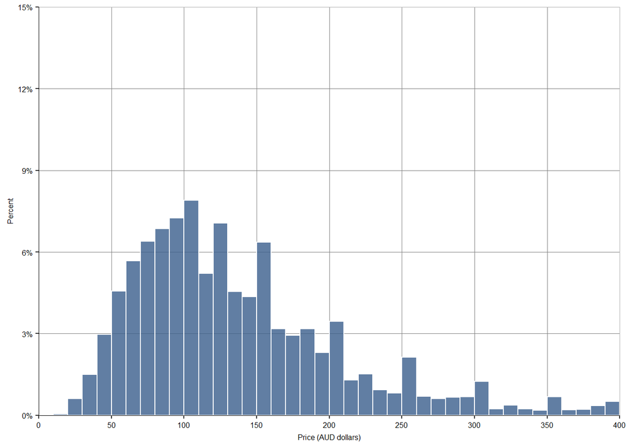

I decided to only use the observations regarding apartments and condominiums because it is the similar to the property of my live data. The table 1 show that the condominium is slightly cheaper than the apartment but not significantly.

| f_property_type | f_room_type | mean_price |
| --- | --- | --- |
| Apartment | Entire_apt | 174.2 |
| Apartment | Private_room | 90.03 |
| Apartment | Shared_room | 50.72 |
| Condominium | Entire_apt | 172.2 |
| Condominium | Private_room | 87.81 |
| Condominium | Shared_room | 47.2 |

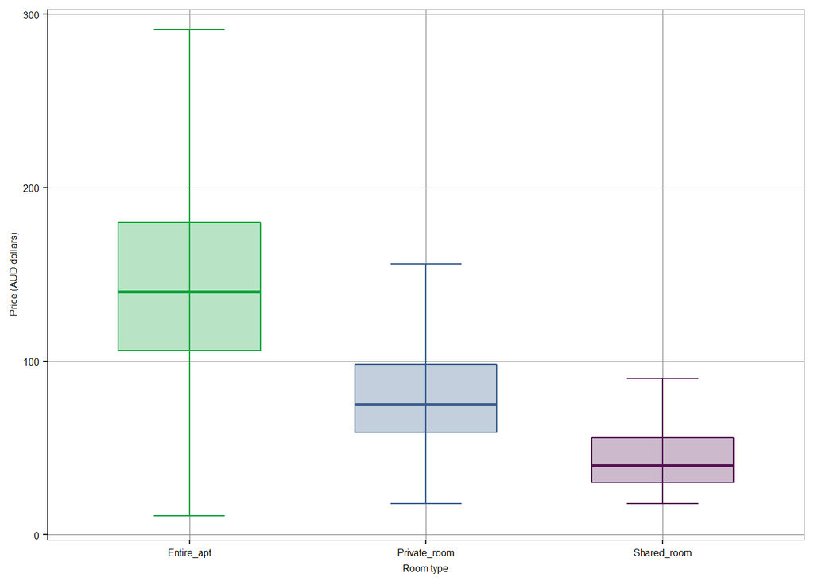

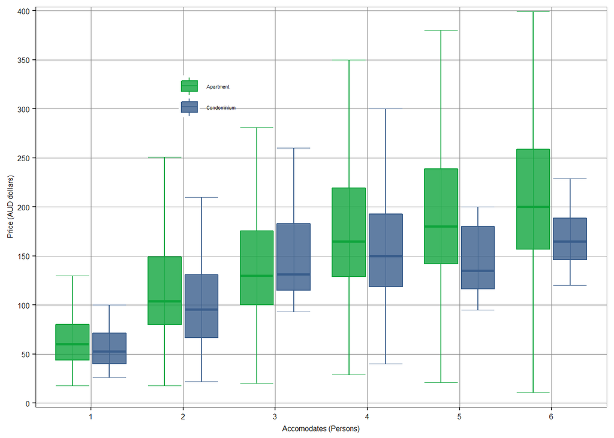

# Predictors

I did not have all the features about the apartment of the owner so I choose my variables on domain knowledge. My predictors variables are compute in five different categories :

#### Facilities

The facilities contains the number of bathrooms and bedrooms and as dummies variable kitchen and garden.

#### Accessibility

The accessibility contains as a factor the minimum of nights and as a dummy the access of a free parking.

#### Reviews

The reviews include the number of reviews as a factor (3 categories: none, 1-51 and >51), the review score rating (min 20 and max 100) and its flag. Indeed, I flag it because I had to compute more than 1000 missing values (I input the median)

#### Amenities

Finally, the airbnb website offers the possibility to show the amenities of apartments. The list of amenities was extremely dense and detailed for some apartments, so I decided to generalize and categorize them into 75 variables and put them as dummies (example of dummies : Tv, Wifi, etc)

# Interactions

For the interaction, I used common sens to choose the candidates. The 8 box-plots below show the chosen interactions. As I can see, only the f_minimum_nights and f_property_type interaction is relevant and I will also include it in my models.

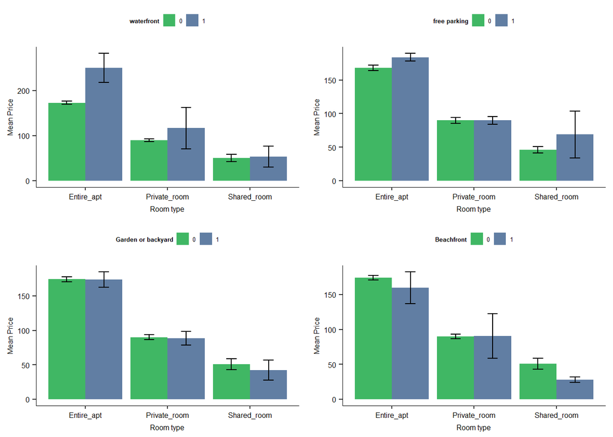

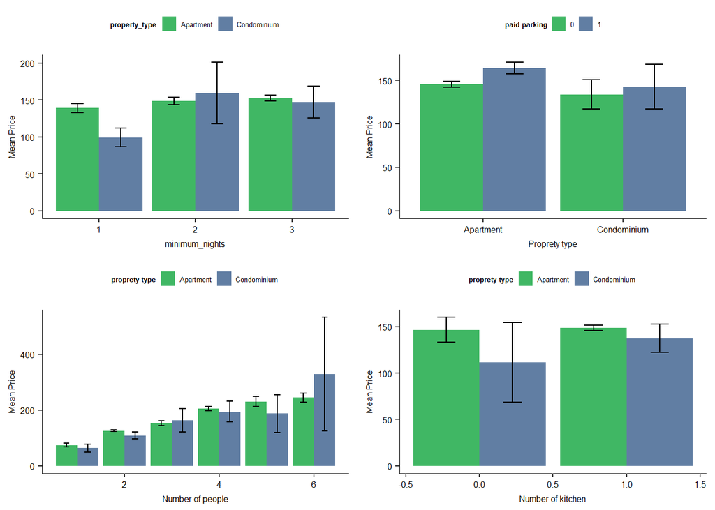

# Models

## OLS

I have specified 7 linear models for predicting the price. I chose different predictor variables for each model. I gradually add an new category at each models.

### OLS Models

modellev1 has as predictor : the accommodates

modellev2 has as predictors : the basic variables

modellev3 has as predictors : the basic variables and the facilities

modellev4 has as predictors : the basic variables, the facilities and the accessibility

modellev5 has as predictors : the basic variables, the facilities, the accessibility and the reviews

modellev6 has as predictors : the basic variables, the facilities, the accessibility, the reviews and the interaction

modellev7 has as predictors : the basic variables, the facilities, the accessibility, the reviews, the interaction and amenities

| rmse_test | rmse_train | model_name | model_pretty_name | nvars | r2 | BIC |
| --- | --- | --- | --- | --- | --- | --- |
| 95.13 | 95.32 | modellev1 | (1) | 1 | 0.1858 | 52176 |
| 92.79 | 92.92 | modellev2 | (2) | 5 | 0.2263 | 51987 |
| 89.66 | 89.54 | modellev3 | (3) | 9 | 0.2813 | 51699 |
| 89.7 | 89.49 | modellev4 | (4) | 11 | 0.2819 | 51712 |
| 89.38 | 89.09 | modellev5 | (5) | 14 | 0.2881 | 51699 |
| 89.39 | 89.09 | modellev6 | (6) | 15 | 0.2882 | 51707 |
| 88.31 | 86.4 | modellev7 | (7) | 80 | 0.328 | 52001 |

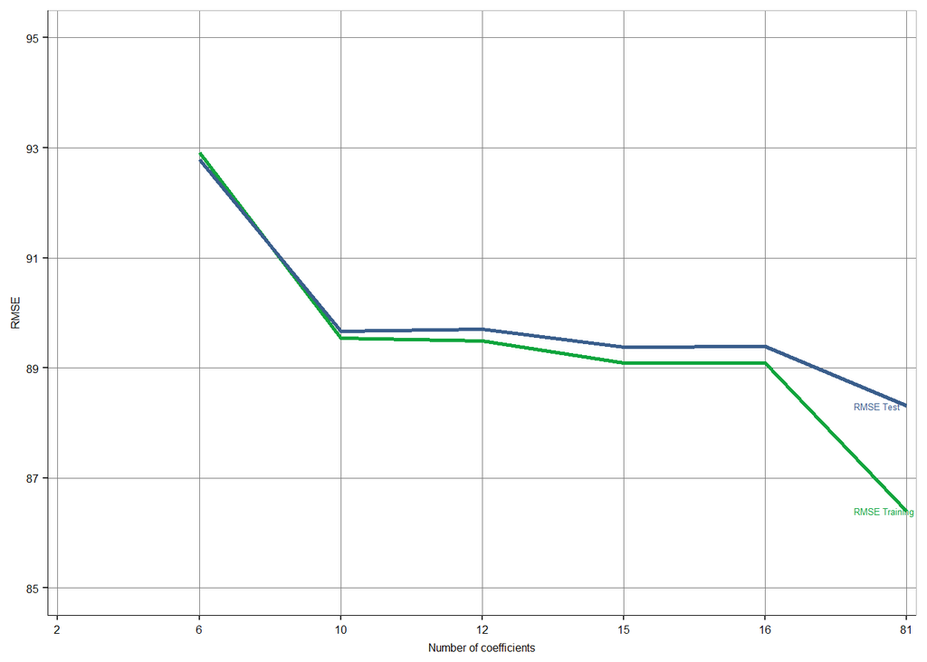

## Random forest

I choose to also used the data only for SydneyB, as it will be easier to compare. It is run with the same 5-fold cross validation. The setting for my Rf in model1 and 2 is to have minimum 5 or 10 observations on my last node and the number of variables to choose from the grid is between 5, 7, 9.

I did 3 models :

rf_model_1 : Same as my model5 : predictors : basic levels ,facilities,Accessibility and reviews

rf_model_2 : same as my model7 without the interactions : basic level ,facilities,Accessibility,reviews and amenities

rf_model_2auto ; same as rf_model_2 except than there is no tuning parameters

I observed that, like in the case study, the difference between the RMSE in each model is very small. So, it confirmed that the random forest try to perform well on the setting parameter value I chose. The model rf_model_2 got the best RMSE (86.9), it is better than Lasso and my model5. The model chose at each intersections between 7 variables and on the last node there were 5 observations. The R square of this model is also better 0,337% compare to 0,2881 for model5.

# Diagnostics

## OLS

In the ols modeling, I chose the model5 as my best model. I can see on the figure 5 the comparison between the predicted price and the actual price. I observed that the model does a better job at predicting for a lower than for a higher price. The predicted values go only until 350 $AUD compare to the real values that go until 800. The OLS had trouble to predict extreme values because they were less common in the data.

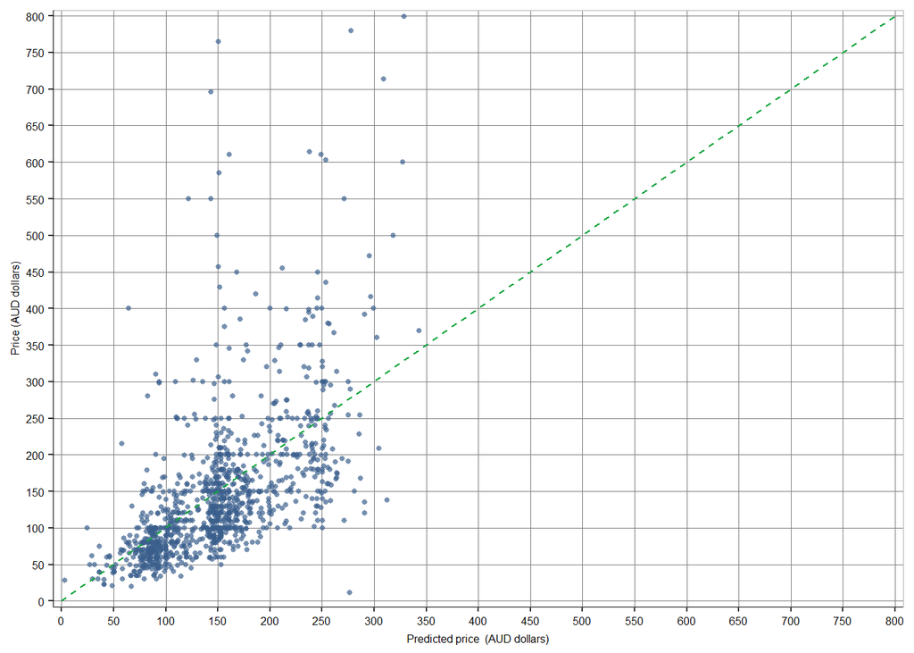

For an average apartment, the model predicted a price of 150 $AUD. The price varies between 35 and 264 AUD dollar. That is a great range of uncertainty.

| fit | pred_lwr | pred_upr |
| --- | --- | --- |
| Min. : 3 | Min. :-112.4 | Min. :118 |
| 1st Qu.:100 | 1st Qu.: -14.3 | 1st Qu.:215 |
| Median :148 | Median : 33.9 | Median :263 |
| Mean :150 | Mean : 35.0 | Mean :264 |
| 3rd Qu.:179 | 3rd Qu.: 64.0 | 3rd Qu.:294 |
| Max. :343 | Max. : 228.5 | Max. :458 |

On the next figure, there is the prediction interval (80% level) by the number of guest that an apartment can accommodate. For a 4 guests apartment, the 80% PI is on average between 100 and 320 $AUD. The prediction interval is really wide. A way to decrease it would be to increase the number of observations in the data, by taking all the neighborhood for example.

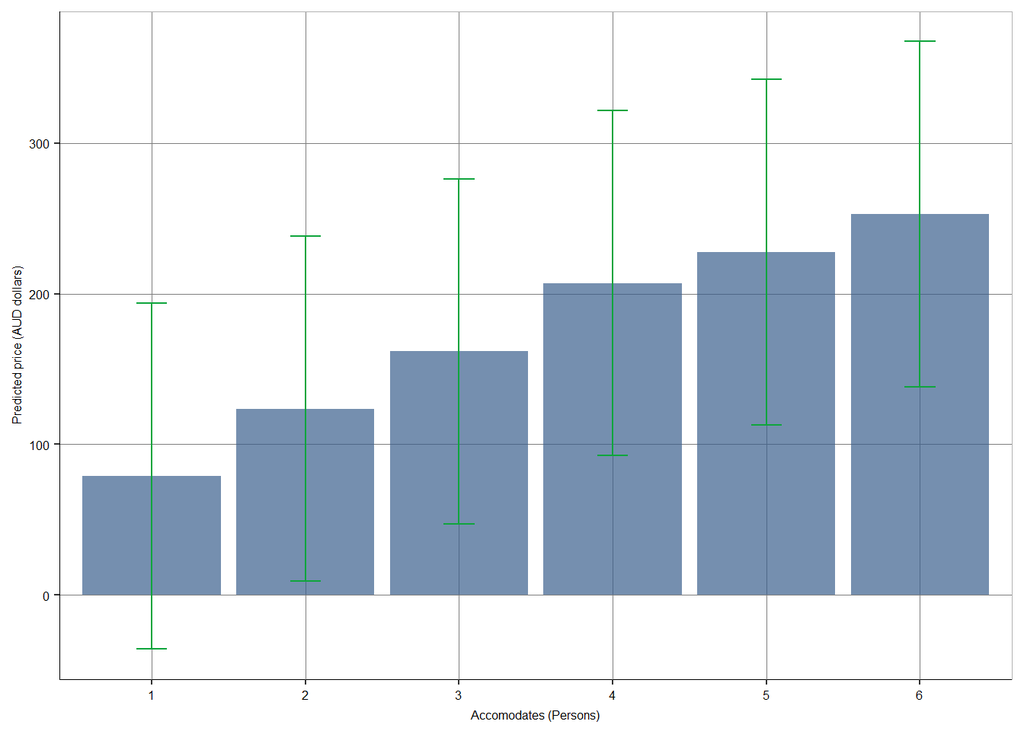

## Random forest

The next figure shows the importance of the variables on the horizontal axis in percentage in the RF. I averaged improvement in the model fit and then divided by its sum across the variables.

[figure not shown]

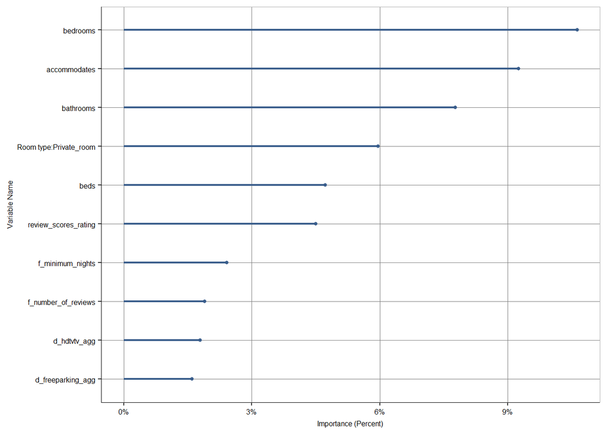

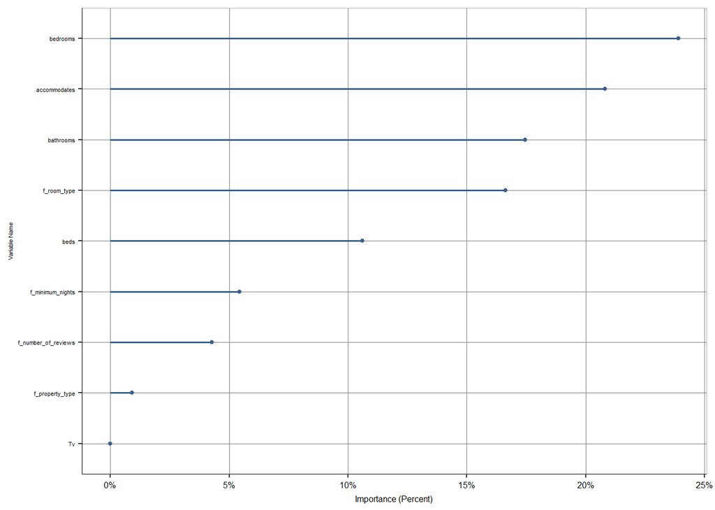

# Conclusion / Summary

This analysis aimed at producing the best prediction of price for an Airbnb apartment in Sydney. I used three different models : OLS, Lasso and Random forest. I carried out a dense cleaning and feature engineering. I chose to conduct the analysis on the neighborhood of Sydney center. From that data, I selected 80% to be my work set and I kept the 20% remaining as the holdout set for the diagnosis at the end. For the OLS, I ran 7 models and the cross-validation. Considering the BIC indicator, the RMSE and the R square, I selected the model 5 : RMSE of 89.38 $AUD with 14 variables. Then, I used Lasso which selected 62 variables and the RMSE was 87.8 $AUD. Finally, I ran 3 models with the random forest. The best models was the model rf_model_2. The RMSE was 87.0 $AUD the model chose at each intersections between 7 variables and on the last node there were 5 observations.(the model was tuned) At the end, I used the holdout set sample with the OLS model5 and I found out that prediction interval is quite wide. For a 4 guests apartment the 80% PI is on average between 100 and 320 $AUD. The model with the best RMSE is the rf_model_2. It was not the case during our case study in London, but the parameters and the choice of the variables have been done differently.